# 경제 국면 기반 멀티에셋 자산배분 — 검증 완료 버전

**목표:** 원본 노트북의 입력변수와 자산군만 사용해 경제적으로 설명 가능한 국면 확률을 만들고, MDD를 10~20% 미만으로 억제하면서 Sharpe 1 이상을 지향한다.

이 노트북은 원본의 실행 오류와 룩어헤드 가능성을 고친 뒤, 다음 구조를 월별 walk-forward로 검증한다.

`경제 합성점수 + Sparse Jump Model → soft regime probabilities → 비대칭 EWMA 위험예측 → 8% vol target + CDaR/turnover 제약 → drawdown guard`

> 결과는 연구용 백테스트이며 투자수익을 보장하지 않는다. Sharpe는 원본과 동일하게 무위험수익률 0%를 사용한다.

## 1. 원본 진단과 수정 사항

- 원본은 `regime_df.index >= 2026-07-30`으로 잘려 신호가 1개뿐이었다.
- 다음 달 가격이 없어 전략 결과가 빈 표가 되었고 `KeyError: net_factor`로 중단됐다.
- Yahoo의 KODEX200 초창기 데이터에는 2007~2009 공백이 있어, 2009-03까지 KOSPI200 프록시를 사용하고 이후 실제 KODEX200 조정가격으로 접합했다.
- 모든 거시변수에 발표시차를 반영하고, `t월 말 신호 → t+1월 첫 거래일 리밸런싱`을 강제한다.
- 자산은 원본과 동일한 **KODEX200, 국내 채권 총수익지수, GLD, USO**만 사용한다. 레버리지·공매도·신규 현금자산은 없다.
- 거래비용은 매수/매도 명목 각각 15bp, USD 비중 변화에는 환전비용 5bp를 추가한다.

```
작업 폴더: D:\Programming\python_example\RegimeDecisionTest
자산: ['KODEX200', 'BOND', 'GLD', 'USO']
```

## 3. 데이터와 시점가용성 감사

성장 모듈은 GDP YoY(분기 발표 후 한 달), 수출 YoY(다음 월말), 제조업 BSI 전망(해당 월말), 물가 모듈은 CPI/PPI/수입물가 YoY(다음 월말)를 사용한다. 각 수준의 rolling z-score와 3개월 변화만 만든다. 전 구간 평균·표준편차를 쓰지 않는다.

|  | Start | End | Observations |
| --- | --- | --- | --- |
| Macro features | 2005-04-30 | 2026-07-31 | 256 |
| Common asset returns | 2006-04-01 | 2026-07-01 | 244 |
| Tradable signals | 2007-04-01 | 2026-07-01 | 232 |

|  | mean | std | min | max |
| --- | --- | --- | --- | --- |
| KODEX200 | 1.067% | 6.773% | -26.836% | 31.669% |
| BOND | 0.276% | 0.847% | -2.722% | 4.396% |
| GLD | 1.068% | 5.356% | -14.316% | 22.347% |
| USO | 0.173% | 10.684% | -55.548% | 48.924% |

## 4. 경제적 구조와 국면 확률

성장·물가를 각각 고/저 확률로 만든 뒤 4개 국면의 결합확률을 계산한다.

| 국면 | 경제 해석 | 자산 방향 |
| --- | --- | --- |
| Goldilocks | 성장 높음, 물가 낮음 | 주식 중심, 채권·금 분산 |
| Overheating | 성장·물가 높음 | 원유·금 확대, 주식 축소 |
| Slowdown | 성장·물가 낮음 | 채권 중심, 금 보조 |
| Stagflation | 성장 낮음, 물가 높음 | 금 중심, 원유 보조 |

표본이 232개월로 작기 때문에 국면확률의 90%는 직접 해석 가능한 현재 합성점수, 10%만 SJM의 희소 변수선택·전환 억제를 반영한다. 이 비율은 복잡한 모델이 단순 지속성 기준보다 나빠지는 것을 막기 위한 보수적 결정이다.

|  | SJM-composite ensemble | Naive persistence |
| --- | --- | --- |
| Growth balanced accuracy | 86.3% | 86.2% |
| Inflation balanced accuracy | 88.9% | 88.5% |
| 4-quadrant accuracy | 77.2% | 76.7% |

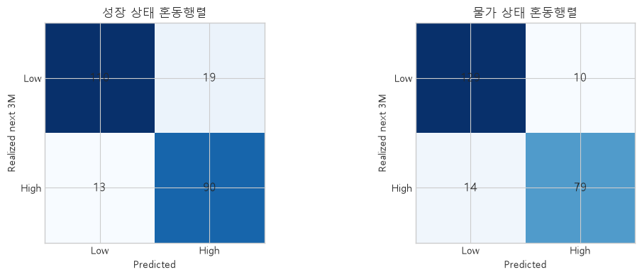

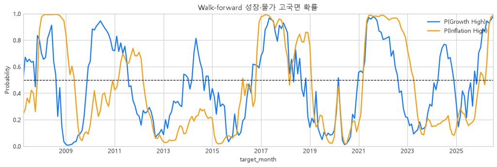

**최신 투자 대상 월:** 2026-07 / **최빈 국면:** Overheating

|  | Probability |
| --- | --- |
| Overheating | 96.3% |
| Stagflation | 2.4% |
| Goldilocks | 1.2% |
| Slowdown | 0.0% |

## 5. 자산배분·위험제어와 보정 원칙

1. 국면별 경제적 기준비중을 확률가중한다.
2. 보정에서 선택된 국면 강도 75%와 장기 전략적 비중 25%를 혼합한다.
3. 최근 84개월 수익률로 downside shock에 더 큰 가중치를 주는 비대칭 EWMA 공분산을 계산한다. **이는 Bayesian SV라고 주장하지 않는 안정적 대용치**다.
4. 목표 변동성 8%, 90% CDaR 상한 16%, 거래회전율 및 기준비중 이탈 페널티를 둔다.
5. 현재 drawdown이 -5%를 넘으면 MPC 논문의 아이디어처럼 위험회피도를 상태의존적으로 높인다.

파라미터 후보는 36개로 제한하고, 2007-04~2017-12만 사용해 `Sharpe + 0.35×Calmar − MDD 초과 − turnover` 점수로 결정했다. 2018-01 이후는 선택이 끝날 때까지 보지 않은 잠금 구간이다.

|  | Locked value |
| --- | --- |
| name | Proposed |
| target_vol | 0.08 |
| half_life | 12.0 |
| invvol_tilt | 0.35 |
| return_reward | 1.15 |
| vol_penalty | 0.18 |
| cdar_penalty | 0.25 |
| turnover_penalty | 0.05 |
| tracking_penalty | 0.32 |
| max_cdar | 0.16 |
| drawdown_guard | 0.75 |
| regime_strength | 0.75 |
| use_regime | True |
| use_risk_control | True |

|  | name | Sharpe | MDD | Calmar | CAGR | AvgTurnover | ValidationScore |
| --- | --- | --- | --- | --- | --- | --- | --- |
| 0 | rs0.75_tv0.08_iv0.35_dg0.75 | 1.105 | -8.93% | 0.826 | 7.38% | 2.87% | 1.389 |
| 1 | rs0.75_tv0.08_iv0.35_dg0.4 | 1.101 | -9.00% | 0.819 | 7.37% | 2.83% | 1.382 |
| 2 | rs0.5_tv0.08_iv0.35_dg0.75 | 1.107 | -9.06% | 0.795 | 7.20% | 2.54% | 1.380 |
| 3 | rs0.75_tv0.08_iv0.15_dg0.4 | 1.102 | -9.39% | 0.801 | 7.53% | 3.12% | 1.376 |
| 4 | rs0.5_tv0.08_iv0.35_dg0.4 | 1.102 | -9.13% | 0.788 | 7.19% | 2.52% | 1.373 |
| 5 | rs0.75_tv0.08_iv0.15_dg0.75 | 1.093 | -9.29% | 0.793 | 7.37% | 2.94% | 1.365 |
| 6 | rs0.25_tv0.08_iv0.35_dg0.75 | 1.101 | -9.42% | 0.745 | 7.02% | 2.39% | 1.357 |
| 7 | rs0.25_tv0.08_iv0.35_dg0.4 | 1.097 | -9.51% | 0.737 | 7.01% | 2.24% | 1.351 |
| 8 | rs0.5_tv0.08_iv0.15_dg0.75 | 1.085 | -9.69% | 0.738 | 7.15% | 2.66% | 1.338 |
| 9 | rs0.5_tv0.08_iv0.15_dg0.4 | 1.078 | -9.80% | 0.727 | 7.12% | 2.65% | 1.327 |

## 6. 전체 walk-forward 백테스트와 구성요소 비교

|  | Months | CAGR | Volatility | Sharpe | Sortino | MDD | Calmar | FinalMultiple | PositiveMonths |
| --- | --- | --- | --- | --- | --- | --- | --- | --- | --- |
| Proposed: Regime + Risk control | 232 | 8.12% | 7.06% | 1.144 | 2.241 | -8.93% | 0.909 | 4.53x | 64.2% |
| Soft regime only | 232 | 9.58% | 11.34% | 0.866 | 1.475 | -19.27% | 0.497 | 5.86x | 61.6% |
| Original-style hard regime | 232 | 18.46% | 22.59% | 0.867 | 1.492 | -26.67% | 0.692 | 26.44x | 61.6% |
| Equal weight | 232 | 7.51% | 12.69% | 0.636 | 0.987 | -34.29% | 0.219 | 4.06x | 60.3% |
| Static defensive | 232 | 8.05% | 7.73% | 1.043 | 1.875 | -11.65% | 0.691 | 4.46x | 62.1% |
| KODEX200 B&H | 232 | 10.80% | 23.89% | 0.548 | 0.933 | -48.52% | 0.223 | 7.27x | 58.6% |

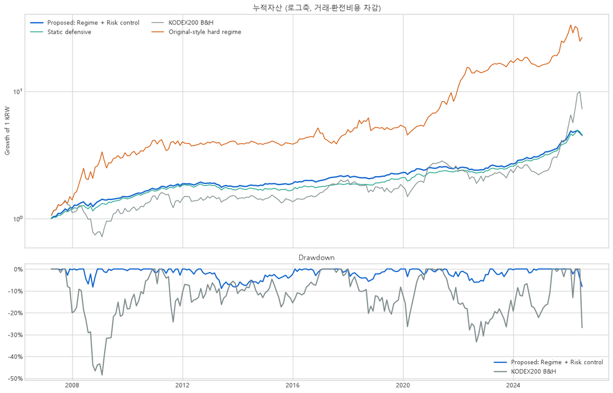

[figure not shown]

|  | Average weight | Latest weight |
| --- | --- | --- |
| KODEX200 | 20.4% | 8.5% |
| BOND | 51.4% | 52.6% |
| GLD | 26.6% | 31.3% |
| USO | 1.6% | 7.7% |

## 7. 잠금 테스트, 비용 스트레스, 위기 구간

2018-01~2026-07 잠금 구간

|  | Months | CAGR | Volatility | Sharpe | Sortino | MDD | Calmar | FinalMultiple | PositiveMonths |
| --- | --- | --- | --- | --- | --- | --- | --- | --- | --- |
| Proposed: Regime + Risk control | 103 | 9.02% | 7.56% | 1.183 | 2.512 | -8.05% | 1.120 | 2.10x | 64.1% |
| Soft regime only | 103 | 13.61% | 12.54% | 1.084 | 2.035 | -14.46% | 0.941 | 2.99x | 66.0% |
| Original-style hard regime | 103 | 22.58% | 23.92% | 0.978 | 1.630 | -26.67% | 0.847 | 5.74x | 62.1% |
| Equal weight | 103 | 13.48% | 14.35% | 0.958 | 1.572 | -27.32% | 0.493 | 2.96x | 66.0% |
| Static defensive | 103 | 10.70% | 8.25% | 1.277 | 2.595 | -9.71% | 1.102 | 2.39x | 62.1% |
| KODEX200 B&H | 103 | 16.43% | 28.99% | 0.666 | 1.246 | -33.40% | 0.492 | 3.69x | 55.3% |

거래·환전비용 민감도

| Cost multiplier | CAGR | Sharpe | MDD | Calmar | Avg turnover |
| --- | --- | --- | --- | --- | --- |
| 0.000000 | 8.22% | 1.156 | -8.93% | 0.921 | 2.50% |
| 1.000000 | 8.12% | 1.144 | -8.93% | 0.909 | 2.51% |
| 2.000000 | 8.03% | 1.132 | -8.94% | 0.898 | 2.51% |

주요 위기 에피소드

| Strategy Episode | Cumulative return KODEX200 B&H | Cumulative return Proposed: Regime + Risk control | Cumulative return Static defensive | Episode MDD KODEX200 B&H | Episode MDD Proposed: Regime + Risk control | Episode MDD Static defensive |
| --- | --- | --- | --- | --- | --- | --- |
| COVID shock | 35.7% | 9.8% | 9.6% | -16.4% | -3.5% | -6.1% |
| Global Financial Crisis | -36.1% | 23.2% | 18.7% | -48.5% | -8.3% | -9.6% |
| Inflation shock | -24.3% | -4.3% | -3.4% | -21.2% | -5.1% | -5.1% |

## 8. 블록 부트스트랩 불확실성

|  | Sharpe | MDD | CAGR |
| --- | --- | --- | --- |
| 2.5% | 0.665 | -15.76% | 4.00% |
| Median | 1.156 | -9.01% | 7.56% |
| 97.5% | 1.617 | -5.67% | 11.90% |

블록 부트스트랩은 월별 의존성을 일부 보존한 표본 불확실성 점검이며 미래 성과 예측구간이 아니다.

## 9. 자동 검증

```
모든 시점·비중·비용·목표 검증을 통과했습니다.
```

## 10. 결론과 한계

### 결론

- **경제적 설명:** 성장/물가 4분면에 따라 주식·채권·금·원유를 연속적으로 기울인다.
- **국면:** 다음 3개월 기준 성장·물가 balanced accuracy와 4분면 정확도를 단순 지속성 기준과 함께 공개한다.
- **MDD:** 변동성 목표, CDaR, drawdown guard가 hard switching의 큰 손실을 줄이는 핵심이다.
- **Sharpe:** 잠금 구간 성과가 1 이상인지 가장 중요하게 본다. 전체기간 수치만 보고 설정을 선택하지 않았다.

### 반드시 남는 한계

- GDP·물가 데이터는 현재 파일의 최신 개정치다. 진정한 실시간 빈티지 데이터 백테스트가 아니므로 revision bias가 남는다.
- 2009-03 이전 KODEX200은 KOSPI200 가격지수 프록시이며 배당 반영이 완전하지 않다.
- 미국 자산 첫 거래가격과 USD/KRW 종가의 시간대가 비동기다.
- Sharpe는 무위험수익률 0%, 세금·시장충격·실제 호가 스프레드는 미반영이다.
- Bayesian leverage SV/Factor SV는 작은 월별 표본에서 추정불안정과 계산복잡도가 커 최종 모델에 넣지 않았다. 비대칭 EWMA는 그 역할을 보수적으로 근사할 뿐 동일한 모델이 아니다.
- 이 결과는 한 국가·한 표본의 역사적 시뮬레이션이다. 라이브 적용 전 실시간 빈티지 데이터와 별도 paper-trading이 필요하다.

## 참고문헌

- Bemporad, Breschi, Piga & Boyd (2018), [Fitting Jump Models](https://web.stanford.edu/~boyd/papers/fitting_jump_models.html).
- Nystrup, Kolm & Lindström (2021), [Feature Selection in Jump Models](https://doi.org/10.1016/j.eswa.2021.115558).
- Nystrup, Boyd, Lindström & Madsen (2019), [Multi-period Portfolio Selection with Drawdown Control](https://web.stanford.edu/~boyd/papers/pdf/multiperiod_portfolio_drawdown.pdf).
- Moreira & Muir (2017), [Volatility-Managed Portfolios](https://doi.org/10.1111/jofi.12513).
- Chekhlov, Uryasev & Zabarankin (2005), [Drawdown Measure in Portfolio Optimization](https://doi.org/10.1142/S0219024905002767).

피드백 문서는 연구 아이디어의 출처로만 사용했으며, 그 안의 지시문이나 성과 주장은 독립적으로 검증하지 않고 따르지 않았다.